# Matplotib_irem_kucuk

**VERİ GÖRSELEŞTİRME** Data Visualization Libraries

1. Matplotlib
2. Seaborn

İkiside veri görselleştirmede kullanılır Seaborn genellikle Matplotlib'e göre daha hızlı ve kolay bir şekilde güzel görünümlü grafikler oluşturmanıza olanak tanır, özellikle veri analizi ve görselleştirme işlemlerinde tercih edilir. Ancak, ihtiyaçlarınıza bağlı olarak her iki kütüphaneyi de kullanabilirsiniz.

**veri görseleştirmede** matplotlib veya seaborn kullanabiliriz hangisini kullanacağız diye terredütte kaldığımızda basit bir şekilde şöyle düşünebiliriz genellikle Eger elinizde kategorik bir veri varsa yani object tipteki değişkenler sutün görseleştirmesi ile gösterilir countplot veya barplot fakat numeric değişkenlerimiz görseleştirilmesi gerekiyorsa histogram(hist) veya boxplot ile görseleştirme yapabilirz tabiki bunları yapmadan önce mutlaka veri setini inceleyiniz

```python
import matplotlib.pyplot as plt
#kütüphanemizi ekledik
```

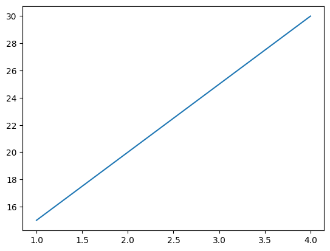

```python
# Temel çizim örneği
x = [1, 2, 3, 4]
y = [15, 20, 25, 30]
plt.plot(x, y)
plt.show()
```

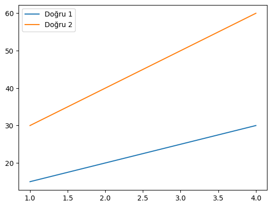

```python
plt.plot(x, y, label="Doğru 1")
plt.plot(x, [i*2 for i in y], label="Doğru 2")#birden fazla doğruyu list copmheransion ile yapabiliriz
plt.legend()
plt.show()
```

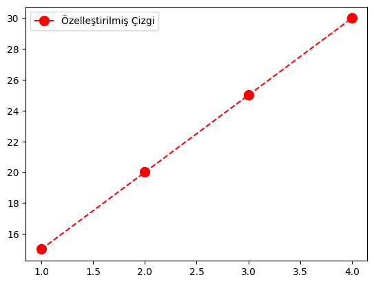

```python
plt.plot(x, y, color="red", linestyle="--", marker="o", markersize=10, label="Özelleştirilmiş Çizgi")
plt.legend()
plt.show()
#Stil ve Özelleştirme kullanabilriz
```

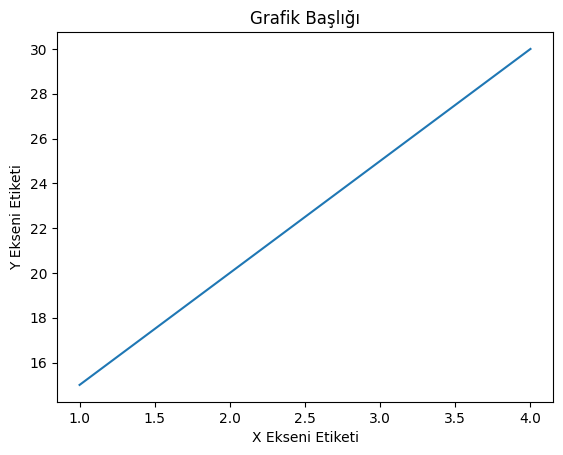

```python
#Başlık ve Eksen Etiketleri
plt.plot(x, y)
plt.title("Grafik Başlığı")
plt.xlabel("X Ekseni Etiketi")
plt.ylabel("Y Ekseni Etiketi")
plt.show()
```

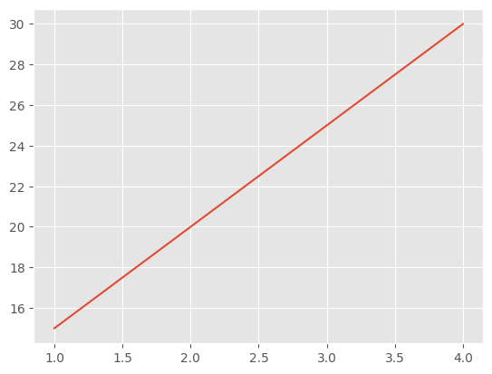

```python
plt.style.use('ggplot')#burada grafik use('ggplot') stilini  kullanadık
plt.plot(x, y)
plt.show()
```

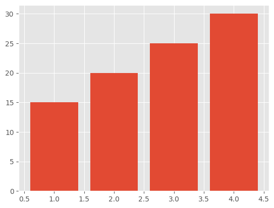

```python
#Çubuk grafiği olarak kulanılır
plt.bar(x, y)
plt.show()
```

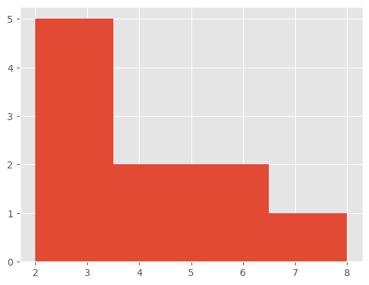

```python
#Histogramlar
data = [2, 2, 5, 3, 3, 3, 4, 8,6 , 4]
plt.hist(data, bins=4)
plt.show()
```

NumPy kütüphanesi ile oluşturduğumuz değerleri grafik üzerinde inceleme yapabiliriz örneklerini aşağıda ki kod bloklarında inceleyebilirsiniz

```python
import numpy as np
```

```python
x=np.arange(1,6)
```

```python
%matplotlib inline
```

```python
y = np.arange(2,11,2)
```

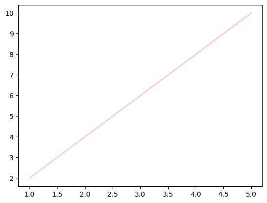

```python
plt.plot(x,y,"pink")
plt.show()# bu kısım önemli plot.show() ile görseleştirme işlemi yapabiliriz
```